# Sevier

Topics that will be discussed in this summary report for Sevier County are

- Demographic Characteristics
  - Population growth from 1970 to 2020;
  - population density
  - sex, race, and age
  - educational level of the adult population
  - housing characteristics in terms of age of the housing stock and type of tenure
- Economic Characteristics
  - family income, household income, per capita income,
  - poverty status of families;
  - employment classification according to industry;
  - labor force by place of work and commuting patterns;

For more details on the data used, please see the Data Description tab.

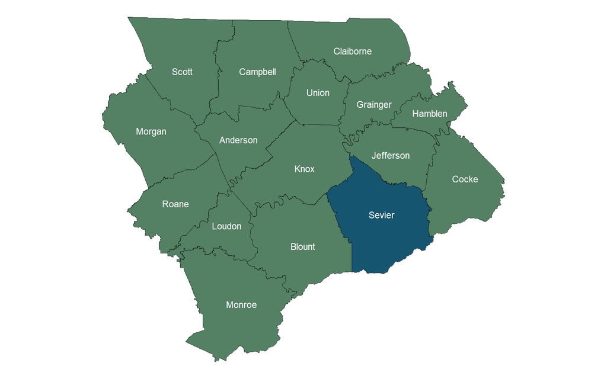

**Population and Growth**

| Place | 1970 | 1980 | 1990 | 2000 | 2010 | 2020 | Change 1970-1980 | Change 1980-1990 | Change 1990-2000 | Change 2000-2010 | Change 2010-2020 |
| --- | --- | --- | --- | --- | --- | --- | --- | --- | --- | --- | --- |
| Sevier County | 28241 | 41418 | 51043 | 71170 | 89889 | 98380 | 13177 | 9625 | 20127 | 18719 | 8491 |
| Gatlinburg | 2329 | 3210 | 3417 | 3382 | 3944 | 3577 | 881 | 207 | -35 | 562 | -367 |
| Pigeon Forge | 1361 | 1822 | 3027 | 5083 | 5875 | 6343 | 461 | 1205 | 2056 | 792 | 468 |
| Pittman Center |  | 488 | 478 | 477 | 502 | 454 |  | -10 | -1 | 25 | -48 |
| Sevierville | 2661 | 4556 | 7178 | 11757 | 14807 | 17889 | 1895 | 2622 | 4579 | 3050 | 3082 |

[interactive chart not shown]

IPUMS NHGIS, University of Minnesota, www.nhgis.org

**Population Density**

| Place | Area | Population Density |
| --- | --- | --- |
| Sevier County | 597.635160909127 | 164.6154818775114 |
| Gatlinburg | 10.41352532242482 | 343.4955876370869 |
| Pigeon Forge | 13.34322175542847 | 475.3724487430824 |
| Pittman Center | 6.008640310229896 | 75.55785944235187 |
| Sevierville | 24.20018363406073 | 739.2092667768848 |

[interactive chart not shown]

source: U. S. Census Bureau *Decennial Census: Redistricting Data (PL 94-171)*, 2020, accessed June 2, 2026, http://api.census.gov/data/2020/dec/pl.

**Population Descriptions**

| Place | Year | Race Category | Number of People | Percentage of People |
| --- | --- | --- | --- | --- |
| Sevier County | 2020 | Black | 812 | 0.006411724295855278 |
| Sevier County | 2020 | Other | 11912 | 0.09405967957170945 |
| Sevier County | 2020 | White | 85656 | 0.6763579510908617 |
| Gatlinburg | 2020 | Black | 15 | 0.0001184431828052083 |
| Gatlinburg | 2020 | Other | 753 | 0.005945847776821458 |
| Gatlinburg | 2020 | White | 2809 | 0.02218046003332201 |
| Pigeon Forge | 2020 | Black | 72 | 0.0005685272774650001 |
| Pigeon Forge | 2020 | Other | 1673 | 0.01321036298887424 |
| Pigeon Forge | 2020 | White | 4598 | 0.03630678363588986 |
| Pittman Center | 2020 | Black | 4 | 3.158484874805556e-05 |

[output cut: 5 more lines]

| Place | Sex | Age Range | Year | Number of People | Percentage of People |
| --- | --- | --- | --- | --- | --- |
| Sevier County | Female | 10 to 14 years | 2020 | 2830 | 0.02243734589190432 |
| Sevier County | Female | 15 to 19 years | 2020 | 2703 | 0.02143044026353971 |
| Sevier County | Female | 20 to 24 years | 2020 | 2594 | 0.02056624566911654 |
| Sevier County | Female | 25 to 29 years | 2020 | 3172 | 0.0251488555367917 |
| Sevier County | Female | 30 to 34 years | 2020 | 2651 | 0.02101816394326443 |
| Sevier County | Female | 35 to 39 years | 2020 | 2710 | 0.02148593899896138 |
| Sevier County | Female | 40 to 44 years | 2020 | 3001 | 0.02379310071434801 |
| Sevier County | Female | 45 to 49 years | 2020 | 3337 | 0.02645704001458824 |
| Sevier County | Female | 5 to 9 years | 2020 | 2467 | 0.01955934004075193 |
| Sevier County | Female | 50 to 54 years | 2020 | 3549 | 0.02813785885878743 |

[output cut: 170 more lines]

[interactive chart not shown]

source: U. S. Census Bureau *Decennial Census: Redistricting Data (PL 94-171)*, 2020, accessed June 2, 2026, http://api.census.gov/data/2020/dec/pl.

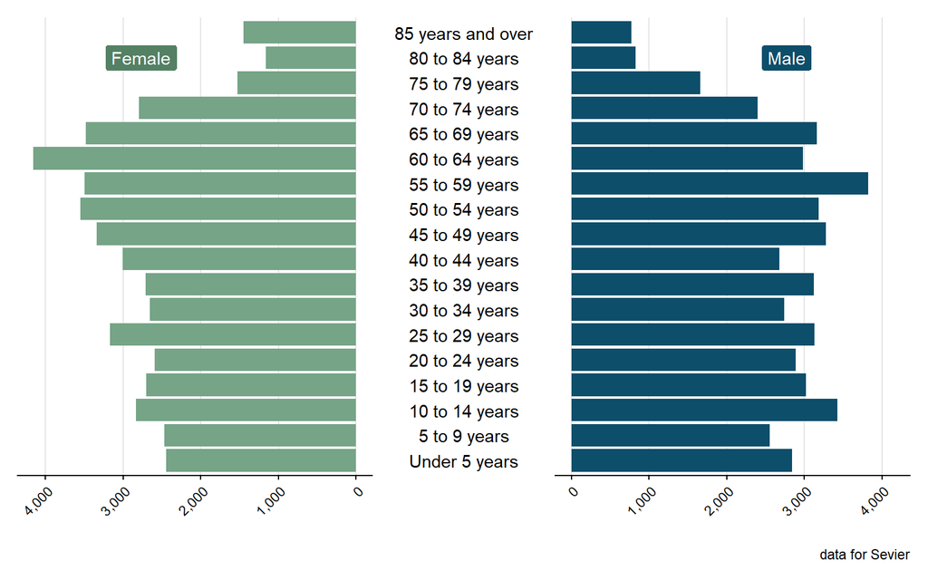

source: U. S. Census Bureau *American Community Survey 5-Year Estimates: Comparison Profiles 5-Year*, 2020, accessed June 2, 2026, http://api.census.gov/data/2020/acs/acs5.

**Education**

| Place | Level of Education | Year | Number of People | Percentage of People |
| --- | --- | --- | --- | --- |
| Sevier County | 9th to 12th Grade, No Diploma | 2010 | 5784 | 0.07399447344181763 |
| Sevier County | Associate's degree | 2010 | 3432 | 0.04390543444887934 |
| Sevier County | Bachelor's degree | 2010 | 5653 | 0.072318595844847 |
| Sevier County | Graduate or Professional Degree | 2010 | 3558 | 0.04551734725207246 |
| Sevier County | Less Than 9th Grade | 2010 | 4434 | 0.05672397912189131 |
| Sevier County | Some College, No Degree | 2010 | 13082 | 0.1673574864394637 |
| Sevier County | Total | 2010 | 60764 | 0.7773513458192611 |
| Sevier County | 9th to 12th Grade, No Diploma | 2020 | 4952 | 0.05491970543873658 |
| Sevier County | Associate's degree | 2020 | 5446 | 0.0603983674917931 |
| Sevier County | Bachelor's degree | 2020 | 8684 | 0.09630911188004614 |

[output cut: 60 more lines]

[interactive chart not shown]

source: U. S. Census Bureau *American Community Survey 5-Year Estimates: Comparison Profiles 5-Year*, 2020, accessed June 2, 2026, http://api.census.gov/data/2020/acs/acs5.

**Housing Units by Year of Construction**

| Place | Year | 1939 or earlier | 1940-1959 | 1960-1979 | 1980 to 1989 | 1990 to 1999 | 2000 to 2004 | 2005 or later | 2000 to 2009 | 2010 or later | Total |
| --- | --- | --- | --- | --- | --- | --- | --- | --- | --- | --- | --- |
| Sevier County | 2010 | 1811 | 2971 | 10170 | 11384 | 15216 | 7732 | 3483 |  |  | 52767 |
| Sevier County | 2020 | 1241 | 2839 | 10216 | 9996 | 14222 |  |  | 16082 | 3565 | 58161 |
| Gatlinburg | 2010 | 189 | 627 | 1222 | 1867 | 1458 | 326 | 21 |  |  | 5710 |
| Pigeon Forge | 2010 | 27 | 516 | 1190 | 911 | 1284 | 689 | 59 |  |  | 4676 |
| Pittman Center | 2010 | 30 | 47 | 110 | 80 | 52 | 28 | 4 |  |  | 351 |
| Sevierville | 2010 | 167 | 305 | 1551 | 2031 | 2359 | 1145 | 534 |  |  | 8092 |
| Gatlinburg | 2020 | 38 | 307 | 1261 | 1463 | 1162 |  |  | 1186 | 192 | 5609 |
| Pigeon Forge | 2020 | 24 | 304 | 1135 | 894 | 1399 |  |  | 1700 | 52 | 5508 |
| Pittman Center | 2020 | 15 | 44 | 173 | 55 | 102 |  |  | 118 | 9 | 516 |
| Sevierville | 2020 | 212 | 372 | 1277 | 1603 | 2214 |  |  | 1957 | 825 | 8460 |

[interactive chart not shown]

source: U. S. Census Bureau *Decennial Census: Redistricting Data (PL 94-171)*, 2020, accessed June 2, 2026, http://api.census.gov/data/2020/dec/pl.

**Housing Units by Type of Tenure**

| Place | Year | Own | Rent | Total |
| --- | --- | --- | --- | --- |
| Sevier County | 2010 | 25813 | 11770 | 37583 |
| Sevier County | 2020 | 27005 | 10988 | 37993 |
| Gatlinburg | 2010 | 1310 | 719 | 2029 |
| Pigeon Forge | 2010 | 1373 | 1123 | 2496 |
| Pittman Center | 2010 | 136 | 66 | 202 |
| Sevierville | 2010 | 3330 | 3533 | 6863 |
| Gatlinburg | 2020 | 1093 | 577 | 1670 |
| Pigeon Forge | 2020 | 1060 | 1154 | 2214 |
| Pittman Center | 2020 | 165 | 61 | 226 |
| Sevierville | 2020 | 3431 | 3268 | 6699 |

[interactive chart not shown]

source: U. S. Census Bureau *Decennial Census: Redistricting Data (PL 94-171)*, 2020, accessed June 2, 2026, http://api.census.gov/data/2020/dec/pl.

**Income Comparison**

| Place | Year | Median Family Income | Median Household Income | Per Capita Income |
| --- | --- | --- | --- | --- |
| Sevier County | 2020 | 61265 | 51734 | 26919 |
| Gatlinburg | 2020 | 53015 | 41037 | 24582 |
| Pigeon Forge | 2020 | 52697 | 48327 | 20463 |
| Pittman Center | 2020 | 60962 | 49500 | 22001 |
| Sevierville | 2020 | 51750 | 43307 | 24337 |

[interactive chart not shown]

source: U. S. Census Bureau *Decennial Census: Redistricting Data (PL 94-171)*, 2020, accessed June 2, 2026, http://api.census.gov/data/2020/dec/pl.

**Povery Status**

| Place | Year | Above Poverty | Below Poverty |
| --- | --- | --- | --- |
| Sevier County | 2020 | 23930 | 2788 |
| Gatlinburg | 2020 | 900 | 38 |
| Pigeon Forge | 2020 | 1351 | 248 |
| Pittman Center | 2020 | 155 | 23 |
| Sevierville | 2020 | 3809 | 616 |

[interactive chart not shown]

source: U. S. Census Bureau *American Community Survey 5-Year Estimates: Comparison Profiles 5-Year*, 2020, accessed June 2, 2026, http://api.census.gov/data/2020/acs/acs5.

**Poverty Status by Family Type**

| Place | Poverty Status | Family Type | Number of Families | Year | Percentage of Families |
| --- | --- | --- | --- | --- | --- |
| Sevier County | Above Poverty | All Families | 23930 | 2020 | 0.7067753558981629 |
| Sevier County | Above Poverty | Female Householder | 2868 | 2020 | 0.08470671628566366 |
| Sevier County | Above Poverty | Female Householder with related children | 1456 | 2020 | 0.04300313072242897 |
| Sevier County | Below Poverty | All Families | 2788 | 2020 | 0.08234390690531042 |
| Sevier County | Below Poverty | Female Householder | 1303 | 2020 | 0.0384842577825034 |
| Sevier County | Below Poverty | Female Householder with related children | 1029 | 2020 | 0.03039163565479355 |
| Gatlinburg | Above Poverty | All Families | 900 | 2020 | 0.02658160552897395 |
| Gatlinburg | Above Poverty | Female Householder | 70 | 2020 | 0.002067458207809085 |
| Gatlinburg | Above Poverty | Female Householder with related children | 55 | 2020 | 0.001624431448992852 |
| Gatlinburg | Below Poverty | All Families | 38 | 2020 | 0.001122334455667789 |

[output cut: 20 more lines]

[interactive chart not shown]

source: U. S. Census Bureau *American Community Survey 5-Year Estimates: Comparison Profiles 5-Year*, 2020, accessed June 2, 2026, http://api.census.gov/data/2020/acs/acs5.

**Employment by Industry**

| Place | Industry | Year | Number of Jobs | Percentage of Jobs |
| --- | --- | --- | --- | --- |
| Gatlinburg | Arts, Entertainment, And Recreation, And Accommodation And Food Services | 2010 | 749 | 0.3420091324200913 |
| Gatlinburg | Arts, Entertainment, And Recreation, And Accommodation And Food Services | 2020 | 791 | 0.2242699177771477 |
| Gatlinburg | Construction | 2010 | 64 | 0.02922374429223744 |
| Gatlinburg | Construction | 2020 | 79 | 0.02239863907003119 |
| Gatlinburg | Educational Services, And Health Care And Social Assistance | 2010 | 158 | 0.07214611872146119 |
| Gatlinburg | Educational Services, And Health Care And Social Assistance | 2020 | 142 | 0.04026084491068897 |
| Gatlinburg | Other Industries | 2010 | 751 | 0.3429223744292237 |
| Gatlinburg | Other Industries | 2020 | 418 | 0.1185143181173802 |
| Gatlinburg | Professional, Scientific, And Management, And Administrative, And Waste Management Services | 2020 | 187 | 0.09434914228052473 |
| Gatlinburg | Retail Trade | 2010 | 468 | 0.2136986301369863 |

[output cut: 45 more lines]

[interactive chart not shown]

source: U. S. Census Bureau *American Community Survey 5-Year Estimates: Comparison Profiles 5-Year*, 2020, accessed June 2, 2026, http://api.census.gov/data/2020/acs/acs5.

**Employment by Industry (Historical)**

| Place | Year | Industry | Number of Jobs | Percentage of Jobs |
| --- | --- | --- | --- | --- |
| Gatlinburg | 2010 | Agriculture, Forestry, Fishing And Hunting, And Mining | 0 | 0 |
| Gatlinburg | 2010 | Construction | 64 | 0.001135214715220746 |
| Gatlinburg | 2010 | Manufacturing | 143 | 0.002536495379321354 |
| Gatlinburg | 2010 | Other | 75 | 0.001330329744399312 |
| Gatlinburg | 2010 | Professional Services | 1074 | 0.01905032193979814 |
| Gatlinburg | 2010 | Public Administration | 111 | 0.001968888021710981 |
| Gatlinburg | 2010 | Trade, Finance, Insurance &amp; Real Estate | 723 | 0.01282437873600937 |
| Gatlinburg | 2020 | Agriculture, Forestry, Fishing And Hunting, And Mining | 0 | 0 |
| Gatlinburg | 2020 | Construction | 79 | 0.001302018953440461 |
| Gatlinburg | 2020 | Manufacturing | 160 | 0.002637000412031314 |

[output cut: 60 more lines]

**Labor Force by Place of Work**

| Place | Year | Work Out Of State | Work Out of County of Residence | Work in County of Residence |
| --- | --- | --- | --- | --- |
| Sevier County | 2020 | 557 | 9564 | 35807 |
| Gatlinburg | 2020 | 29 | 76 | 1833 |
| Pigeon Forge | 2020 | 14 | 37 | 3315 |
| Pittman Center | 2020 | 0 | 26 | 307 |
| Sevierville | 2020 | 16 | 731 | 6807 |

[interactive chart not shown]

source: U. S. Census Bureau *American Community Survey 5-Year Estimates: Comparison Profiles 5-Year*, 2020, accessed June 2, 2026, http://api.census.gov/data/2020/acs/acs5.

**Commuting Patterns**

| Home County | Year | Number of Jobs | Percentage of Jobs |
| --- | --- | --- | --- |
| Sevier | 2020 | 23137 | 0.2964077993287043 |
| Sevier | 2010 | 20855 | 0.2671731276742935 |
| Knox | 2020 | 5018 | 0.06428553127161854 |
| Knox | 2010 | 3599 | 0.0461067411412027 |
| Blount | 2020 | 2001 | 0.0256347843910938 |
| Blount | 2010 | 1476 | 0.01890901637244101 |
| Hamblen | 2020 | 863 | 0.01105588152399498 |
| Hamblen | 2010 | 554 | 0.007097286633016475 |
| Davidson | 2010 | 479 | 0.00613646263035179 |
| Davidson | 2020 | 350 | 0.004483845345768531 |

[output cut: 3 more lines]

| Work County | Year | Number of Jobs | Percentage of Jobs |
| --- | --- | --- | --- |
| Sevier | 2020 | 23137 | 0.2964077993287043 |
| Sevier | 2010 | 20855 | 0.2671731276742935 |
| Knox | 2020 | 8418 | 0.1078428860590843 |
| Knox | 2010 | 8116 | 0.1039739680750211 |
| Blount | 2020 | 1735 | 0.02222706192830972 |
| Blount | 2010 | 1243 | 0.01592405647082938 |
| Jefferson | 2020 | 619 | 0.007930000768659202 |
| Jefferson | 2010 | 596 | 0.007635348074508699 |
| Cocke | 2020 | 311 | 0.003984216864382895 |
| Cocke | 2010 | 261 | 0.003343667529273105 |

[output cut: 3 more lines]

[interactive chart not shown]

source: U. S. Census Bureau *Tn_od_main_JT00_2020*, LEHD Origin-Destination Employment Statistics, 8.3, 2020, accessed June 2, 2026, https://lehd.ces.census.gov/data/lodes/.

## References

Bureau, U. S. Census. *American Community Survey 5-Year Estimates: Comparison Profiles 5-Year*. 2020. Accessed June 2, 2026. http://api.census.gov/data/2020/acs/acs5.

Bureau, U. S. Census. *Decennial Census: Redistricting Data (PL 94-171)*. 2020. Accessed June 2, 2026. http://api.census.gov/data/2020/dec/pl.

Bureau, U. S. Census. *Tn_od_main_JT00_2020*. LEHD Origin-Destination Employment Statistics, 8.3. 2020. Accessed June 2, 2026. https://lehd.ces.census.gov/data/lodes/.